# 第一次電腦作業

作業除了讓同學檢視課堂所學程式外，有些題目只會給你未教過的函數建議（純為建議，你也可以不使用），你必需使用Help或網路查尋去了解函數的正確使用；搜詢正確程式函數使用的能力，也是程式設計的基本功。

教育與薪資

一開始請執行

```r
rm(list=ls())
library(dplyr)
library(ggplot2)
```

1. 下載作業中有一個資料檔pp.csv，請將它引入R且資料名稱叫做pums以方便後續討論。[hint: 可使用environment視窗的Import Datasets選單按鍵，但記得把對應程式貼進作業檔]

```r
library(readr)
pums<-read.csv("pp.csv")
View(pums)
```

> 作業資料來自美國1980年針對中年白人勞動者的調查，這裡我們關心的Y變數是以2003年為基期的實質每週薪資(wklywge)，X變數是教育年限(educ). 我們想找出教育的報酬有多高？也就是多受點教育，薪資可以提高多少？
2. 初步觀察wklywge與educ這兩個變數，你注意到什麼？可自由發揮所挔據的觀察，可以是統計量或是圖形。

```r
library(psych)
describe(pums)
```

```
        vars     n    mean      sd  median trimmed     mad   min      max    range  skew
X          1 10000 5000.50 2886.90 5000.50 5000.50 3706.50  1.00 10000.00  9999.00  0.00
educ       2 10000   12.77    3.29   12.00   12.75    2.97  0.00    20.00    20.00 -0.01
yob        3 10000   34.59    2.93   35.00   34.61    4.45 30.00    39.00     9.00 -0.05
qob        4 10000    2.50    1.11    3.00    2.50    1.48  1.00     4.00     3.00 -0.01
pob        5 10000   30.98   14.13   34.00   31.49   14.83  1.00    56.00    55.00 -0.26
wklywge    6 10000  439.49  345.72  384.71  403.12  171.11  0.29 12000.83 12000.54 12.02
        kurtosis    se
X          -1.20 28.87
educ        0.54  0.03
yob        -1.27  0.03
qob        -1.34  0.01
pob        -0.82  0.14
wklywge   287.19  3.46
```

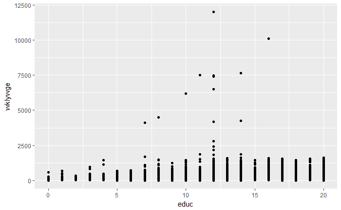

```r
pums %>%
  ggplot(aes(x=educ,y=wklywge))+geom_point()
```

> 我們只打算分析拿到高中學歷與大學學歷的薪資差異，令educ=12為高中學歷，而educ=16為大學學歷。
3. 使用dplyr裡的filter()留下符合條件的樣本，且樣本取名為pums2。[Hint: 此題需要了解邏輯判斷程式規則，同學可以參考https://cran.r-project.org/doc/manuals/r-release/R-intro.pdf裡的2.4節Logical vectors。要注意的是，要判斷是否educ為12，要寫成educ==12，而非educ=12]

```r
pums2<-pums %>%
  filter(educ==12|educ==16)
View(pums2)
```

以下問題請使用pums2資料

4. 在pums2產生一個college虛擬變數，college為1若educ=16。接著檢視該變數的class。

```r
college<-pums2$educ==16
class(college)
```

```
[1] "logical"
```

> 要進行分群分析時，我們可以使用dplyr::group_by()來產生分群資料，之後用dplyr::summarise()來產生各別群組的特徵值。如 dd %>% group_by(x) %>% summarise(mean(y)) 代表「使用資料dd，依其中的x變數分群，並計算各群組y變數的平均值。
5. 觀察pums2不同學歷下的平均薪資與其離散度，你發現什麼？

```r
pums2 %>%
  group_by(educ)%>%
  summarise(mean(wklywge))
```

| educ | mean(wklywge) |
| --- | --- |
| 12 | 405.7229 |
| 16 | 591.3241 |

6. 薪資研究多採用取對數轉換後的薪資，請產生取對數後的薪資變數，並取名為lwklywge。[Hint: 使用log()函數]

```r
lwklywge<-log(pums2$wklywge)
```

7. 請使用簡單迴歸來估計college對lwklywge的影響，並討論其顯著度。

```r
model<-lwklywge~college
outpout1<-lm(model,data=pums2)
summary(outpout1)
```

```
Call:
lm(formula = model, data = pums2)

Residuals:
    Min      1Q  Median      3Q     Max
-4.6393 -0.2396  0.0754  0.3187  3.5399

Coefficients:
            Estimate Std. Error t value Pr(>|t|)
(Intercept) 5.852826   0.009464  618.42   <2e-16 ***
collegeTRUE 0.384275   0.020468   18.77   <2e-16 ***
---
Signif. codes:  0 ‘***’ 0.001 ‘**’ 0.01 ‘*’ 0.05 ‘.’ 0.1 ‘ ’ 1

Residual standard error: 0.581 on 4792 degrees of freedom
Multiple R-squared:  0.06852,   Adjusted R-squared:  0.06832
F-statistic: 352.5 on 1 and 4792 DF,  p-value: < 2.2e-16
```

8. 考慮迴歸殘差的有異質變異，且此變異可以被college捕捉。請針對簡單迴歸模型進行FGLS估計。

```r
library(sandwich)
library(lmtest)
library(nlme)
output2<-gls(model,data=pums2,weights = varExp(form = ~college))
summary(output2)
```

```
Generalized least squares fit by REML
  Model: model
  Data: pums2
       AIC      BIC    logLik
  8411.955 8437.854 -4201.977

Variance function:
 Structure: Exponential of variance covariate
 Formula: ~college
 Parameter estimates:
      expon
-0.06493121

Coefficients:
               Value   Std.Error  t-value p-value
(Intercept) 5.852826 0.009589802 610.3177       0
collegeTRUE 0.384275 0.019721598  19.4850       0

 Correlation:
            (Intr)
collegeTRUE -0.486

Standardized residuals:
       Min         Q1        Med         Q3        Max
-7.8800361 -0.4185048  0.1307430  0.5482252  6.0126920

Residual standard error: 0.5887389
Degrees of freedom: 4794 total; 4792 residual
```

9. 針對上題的異質變異進行BP檢定。

```r
bptest(model,varformula = ~college,data = pums2)
```

```
    studentized Breusch-Pagan test

data:  model
BP = 1.2229, df = 1, p-value = 0.2688
```

10. 針對簡單迴歸模型，討論college係數可能有偏估的原因。[非電腦題，請用文字論述。]